# Incidencia de la maternidad en la emplebilidad de las mujeres en edad de trabajar en Costa Rica durante el segundo III trimestre del 2021 al II trimestre del 2023.

# Librerias.

Se llama a las librerias a implementar en el código.

```r
library(openxlsx)
library(purrr)
library(tidyr)
library(ggplot2)
library(ggmosaic)
library(readxl)
library(rcompanion)
library(dplyr)
library(DescTools)
```

# Datos

## Obtención de Variables

Inicialmente se guardan las rutas de los archivos excel en las variables de ruta. Se obtienen los nombres de las hojas y finalmente se leen y guardan en una lista.

```r
Ruta<- "C:/Users/svm12/Documents/Datos_proyecto_estadistica/Variables_a_usar_letras.xlsx"
hojas = getSheetNames(Ruta)

Ruta2 <- "C:/Users/svm12/Documents/Datos_proyecto_estadistica/Variables_utilizadas_con_porcentajes.xlsx"
hojas2 = getSheetNames(Ruta2)

#Ruta3 <- "C:/Users/svm12/Documents/Datos_proyecto_estadistica/datos_mosaico.xlsx"

list_of_df <- map(hojas,function(x){
  read.xlsx(Ruta ,sheet = x)
})

list_of_df2 = map(hojas2,function(x){
  read.xlsx(Ruta2 ,sheet = x)
})

#mosaic_df <- read.xlsx(Ruta3)
```

## Formateo de datos

El siguiente código crea tablas de contingencia de manera individual, que contienen información sobre dos variables categóricas para todo el período considerado: la condición de tener hijos o no ó la tenencia de pareja de la mujer con hijos, estas se emparejan con el resto de las variables. Posteriormente, se ejecutan sobre las tablas de contingencia las pruebas: Chi-cuadrado, V de cramer y Coeficiente de contingencia de Pearson mediante las funciones `chisq.test()`, `cramerV()`. Esto con el objetivo de observar si existe dependencia o no en cada par de variables.

Función encargada de verificar el tipo de condición en términos de 0, 1 y 2.

`@param condition`: Es una variable que puede ser un valor entero o un string con el tipo de condición. `@return` Retorna un entero con el tipo de condición en términos de 0, 1 y 2.

```r
type_c <- function(condition){
  if(condition == 0 | condition == "Sin hijos" | condition == "Sin pareja" |
     condition == "0 a 5"){
    return(0)
  } else if(condition == 1 | condition == "Con hijos" |
            condition == "Con pareja" | condition == "6 a 14"){
    return(1)
  } else {
    return(2)
  }

}
```

`@param table`: Es un dataframe con la información a convertir en tabla. `@return` Retorna una tabla de contingencia con el contenido del dataframe ingresado.

```r
df_to_table <- function(table){
  condiciones <- (length(table[[1]]) / 8)
  result<-matrix(0,nrow = condiciones , ncol = (length(table) - 3))

  if(condiciones == 3 ){
    for(i in 1:length(table[[1]])){
      for(j in 1:(length(table) - 3)){
        if(type_c(table[i,3]) == 0){
          result[1,j] = result[1,j] + table[[j+3]][i]
        } else if(type_c(table[i,3]) == 1){
          result[2,j] = result[2,j] + table[[j+3]][i]
        } else {
          result[3,j] = result[3,j] + table[[j+3]][i]
        }
      }
    }
  } else {
    for(i in 1:length(table[[1]])){
      for(j in 1:(length(table) - 3)){
        if(type_c(table[[3]][i]) == 1){
          result[1,j] = result[1,j] + table[[j+3]][i]
        } else{
          result[2,j] = result[2,j] + table[[j+3]][i]
        }
      }
    }
  }

  result <- as.table(result)
  if(condiciones == 3){
    x1 <- table[1,3]
    x2 <- table[2,3]
    x3 <- table[3,3]
    dimnames(result) <- list(Condicion=c(x1, x2, x3), colnames(table[1,4:length(table)]))
  } else {
    x1 <- table[1,3]
    x2 <- table[2,3]
    dimnames(result) <- list(Condicion=c(x1, x2), colnames(table[1,4:length(table)]))
  }

  return(result)
}
```

Esta función se encarga de generar todas las tablas de contingencia requeridas para la investigación haciendo uso de la función ya creada `df_to_table()`.

`@param dfs`: Es una lista que contiene los dataframes a convertir. `@return` Retorna una lista con las tablas de contingencia.

```r
dfs_to_tables <- function(dfs){
  tables <- list()
  for(i in 1:length(dfs)){
    tables[[i]] <- df_to_table(dfs[[i]])
  }
  return(tables)
}
```

Se generan las tablas de contingencia sobre las variables a utilizar.

```r
tables_to_use <- dfs_to_tables(list_of_df)
```

# Pruebas de Independencia

Con el objetivo de verificar la dependencia entre las variables estudiadas con respecto al empleo de las mujeres con hijos, se realiza mediante la inferencia estadística sobre la base de datos seleccionada la prueba Chi-cuadrado. Sin embargo, identificar la existencia de dependencia entre variables no es suficiente para responder la pregunta de investigación pues, se quiere verificar el nivel de incidencia sobre el empleo de las madres, por tanto, para este fin se realizan las siguientes pruebas que permiten identificar el nivel de asociación entre las variables: V de Cramer y Coeficiente de Contingencia de Pearson.

## Prueba Chi-Cuadrado

En la prueba Chi-cuadrado, el resultado del p-valor determinará la aceptación o rechazo de la hipótesis nula (Independencia entre variables). En caso de que el p-valor sea menor a 0.05, entonces se rechaza la hipótesis nula y por ende se acepta el criterio de que son variables dependientes.

Esta función corre la prueba chi-cuadrado en todas la tablas y guarda los los resultados en una lista.

`@param tables`: Es una lista de tablas de contingencia. `@return` Retorna una lista con el p-valor de la prueba sobre cada tabla de contingencia.

```r
chi_tests <- function(tables){
  results <- list()
  for(i in 1:length(tables)){
    results[[i]] <- chisq.test(tables[[i]])$p.value
  }
  return(results)
}
```

Resultado para Chi-cuadrado

```r
chi_test_results <- chi_tests(tables_to_use)
```

## Prueba V de Cramer

La V de Cramer indica niveles de dependencia entre variables, es decir qué tan fuerte es la relación entre ellas. Donde los coeficientes de la V de Cramer cercanos a 0 indican una relación muy débil y cercanos a 1, una relación más fuerte. En el caso de los estudios de ciencias sociales, según Fierro 2010, se establecen ciertas convenciones tales como que los valores menores o iguales a 0.2 indican asociación baja, entre 0.2 y 0.3 una asociación moderada y para los coeficiente mayores o iguales a 0.3 una asociación alta.

Esta función se encarga de correr la prueba de la V de Cramer sobre todas las tablas.

`@param tables`: Es una lista de tablas. `@return` Retorna una lista con los resultados de la prueba sobre cada tabla.

```r
cramerv_test <- function(tables){
  results <- list()
  for(i in 1:length(tables)){
    results[[i]] <- cramerV(tables[[i]])
  }
  return(results)
}
```

Resultado para la prueba V de Cramer

```r
cramerv_test_results <- cramerv_test(tables_to_use)
```

## Prueba Coeficiente de Contingencia de Pearson

Dado que la prueba V de Cramer puede subestimar la relación entre las variables, se decide realizar este otro test. El Coeficiente de contingencia de Pearson, similarmente a la prueba V de Cramer, mide el nivel de relación entre variables sin ser afectado por el tamaño de la muestra. En esta prueba, mientras más cercano al 0, menor relación y mientras más cerca del 1, mayor relación.

Esta función se encarga de correr la prueba del coeficiente de contingencia sobre todas las tablas.

`@param tables`: Es una lista de tablas. `@return` Retorna una lista con los resultados de la prueba sobre cada tabla.

```r
coefinciet_test <- function(tables){
  results <- list()
  for(i in 1:length(tables)){
    chi <- chisq.test(tables[[i]])
    results[[i]] <- unname(sqrt(chi$statistic / (chi$statistic + sum(tables[[i]]))))

  }
  return(results)
}
```

Resultado para la prueba del coeficiente de contingencia

```r
coefinciet_results <- coefinciet_test(tables_to_use)
```

## Resultados

Se unen los resultados de todos los tests realizados:

```r
results <- cbind(chi_test_results, unname(unlist(cramerv_test_results)),
                 coefinciet_results)
```

Se crea un data frame con los tests realizados y sus resultados sobre cada variable.

```r
row_names <- c("Nivel educativo de las mujeres desocupadas según la tenencia de hijos", "Nivel educativo de las mujeres ocupadas según la tenencia de hijos", "Nivel educativo de las mujeres de acuerdo al rango de esdad de los hijos", "Jornada de trabajo de las madres de acuerdo a la tenencia de pareja", "Jornada de trabajo de las madres de acuerdo al rango de edad de los hijos", "Jornada de trabajo de las mujeres ocupadas de acuerdo a la tenencia de hijos", "La edad de las mujeres desocupadas de acuerdo a la tenencia de hijos", "La edad de las mujeres ocupadas de acuerdo a la tenencia de hijos", "La edad de las mujeres de acuerdo con el rango edad de los hijos", "Calificación del grupo ocupacional de acuerdo a la tenencia de hijos", "Calificación del grupo ocupacional de acuerdo al rango de edad de los hijos", "Formalidad del trabajo de acuerdo a la tenencia de hijos", "Formalidad del trabajo de acuerdo al rango de edad de los hijos", "Experiencia laboral de las mujeres desocupadas de acuerdo a la tenencia de hijos")
```

```r
df <- data.frame(results)
colnames(df) <- c("Chi-cuadrado", "V de cramer",
                  "Coeficiente de contingencia")
rownames(df) <- row_names
knitr::kable(df, format = "markdown")
```

|  | Chi-cuadrado | V de cramer | Coeficiente de contingencia |
| --- | --- | --- | --- |
| Nivel educativo de las mujeres desocupadas según la tenencia de hijos | 0 | 0.4178 | 0.3854995 |
| Nivel educativo de las mujeres ocupadas según la tenencia de hijos | 0 | 0.3367 | 0.3190744 |
| Nivel educativo de las mujeres de acuerdo al rango de esdad de los hijos | 0 | 0.1485 | 0.2055538 |
| Jornada de trabajo de las madres de acuerdo a la tenencia de pareja | 0 | 0.02755 | 0.02754388 |
| Jornada de trabajo de las madres de acuerdo al rango de edad de los hijos | 0 | 0.03751 | 0.03748138 |
| Jornada de trabajo de las mujeres ocupadas de acuerdo a la tenencia de hijos | 0 | 0.1626 | 0.1604724 |
| La edad de las mujeres desocupadas de acuerdo a la tenencia de hijos | 0 | 0.6024 | 0.5159773 |
| La edad de las mujeres ocupadas de acuerdo a la tenencia de hijos | 0 | 0.4566 | 0.415349 |
| La edad de las mujeres de acuerdo con el rango edad de los hijos | 0 | 0.5495 | 0.4815984 |
| Calificación del grupo ocupacional de acuerdo a la tenencia de hijos | 0 | 0.1911 | 0.1877033 |
| Calificación del grupo ocupacional de acuerdo al rango de edad de los hijos | 0 | 0.08334 | 0.1170446 |
| Formalidad del trabajo de acuerdo a la tenencia de hijos | 0 | 0.1716 | 0.1690846 |
| Formalidad del trabajo de acuerdo al rango de edad de los hijos | 0 | 0.08015 | 0.07989129 |
| Experiencia laboral de las mujeres desocupadas de acuerdo a la tenencia de hijos | 0 | 0.3942 | 0.3667133 |

En el caso de la prueba Chi-Cuadrado todos los casos analizados obtuvieron un p-valor menor a 0.05, por lo que se rechaza la hipótesis nula y por ende, se acepta el criterio de que son variables dependientes. De esta manera se responde al segundo objetivo de la investigación. Por ejemplo, con un nivel de confianza del 95 % se afirma que la condición de tener hijos o no está asociado al nivel educativo de las mujeres desocupadas. También, que el estado conyugal de la mujer con hijos está vinculado con su jornada de trabajo.

En cuanto a los resultados de la V de Cramer y del Coeficiente de Contingecia de Pearson resulta evidente la variedad en los niveles de dependencia. Se puede ver que existe una relación alta entre la edad de la mujer y la condición de tener hijos o no y entre la edad de la mujer y la edad de los hijos. No obstante, contrario a lo observado en otros estudios, la jornada laboral muestra una relación débil con la condición de tener hijos o no. Una interprestación de ello, se basa en el analisísi de los gráficos de barras, pues en la figura sobre la edad de las mujeres desocupadas de acuerdo a la tenencia de hijos, visible en la sección de Gráficos de barras porcentuales, es posible observar que para el caso de las mujeres desocupadas se muestra una tendencia a que conforme aumenta la edad de la mujer hay una mayor inclinación a tener hijos que a no tenerlos. Siendo observable que para el rango de edad entre los 15 a 24 años la mayoría de mujeres no tienen hijos, mientras tanto, para los otros dos rangos de edad se da un notable cambio a tener hijos. Por otro lado, para las mujeres ocupadas se refleja en el gráfico sobre la edad de las mujeres ocupadas de acuerdo a la tenencia de hijos, una preferencia a no tener hijos en las edades tempranas pues apenas están ingresando en el mercado laboral las cuales corresponden a las mujeres de 15 a 24 años y de 25 a 44 años. Caso contrario para las mujeres en el rango de edad más alto donde es posible observar que la mayoría tienen hijos. Esto puede deberse a como indica Gallardo (2021) que las mujeres que trabajan muchas veces desean aplazar la tenencia de hijos con el propósito de alcanzar una buena estabilidad laboral y por ende económica para sus futuros hijos. También, es importante considerar el comportamiento que refleja la edad de los hijos para las madres que trabajan, así, en el gráfico sobre la edad de las mujeres de acuerdo con el rango de edad de los hijos, se evidencia que las mujeres jóvenes tienen una predisposición a tener hijos pequeños, es decir, de 0 a 5 años y para las mujeres de 35 años o más la mayoría tiene hijos de 15 años o más. En general, esto puede implicar que la mayoría de mujeres ocupadas suelen tener hijos a una joven edad.

En síntesis, en respuesta al tercer objetivo de investigación se tiene que de acuerdo con los resultados obtenidos de la V de Cramer y el Coeficiente de Contingencia de Pearson, se determina que los factores de mayor incidencia son:

- Nivel educativo de las mujeres desocupadas según la tenencia de hijos.
- Nivel educativo de las mujeres ocupadas según la tenencia de hijos.
- La edad de las mujeres desocupadas de acuerdo a la tenencia de hijos.
- La edad de las mujeres ocupadas de acuerdo a la tenencia de hijos.
- La edad de las mujeres de acuerdo con el rango edad de los hijos.
- Experiencia laboral de las mujeres desocupadas de acuerdo a la tenencia de hijos.

Finalmente, para corroborar que el modelo se encuentra bien ajustado, se toma en cuenta el sesgo de selección el cual viene por defecto incluido en la prueba V de Cramer hecha sobre las tablas de contingencia. Además, como refuerzo se ejecutó la prueba Coeficiente de Contingencia de Pearson la cual ayudó a identificar la similitud entre los resultados y validar los que se obtuvieron de la V de Cramer.

# Gráficos

Esta función se encarga de transformar las tablas de contingencia para porder generar los gráficos de barras en términos procentuales.

`@param tables`: Es una lista con las tablas de contingencia. `@return`: Retorna las tablas modificadas.

```r
tables_for_barplots <- function(tables){
  results <- list()
  for(i in 1:length(tables)){
    results[[i]] <- prop.table(tables[[i]], margin = 1)
  }
  return(results)
}

tables_barplots <- tables_for_barplots(tables_to_use)
```

## Gráficos de puntos

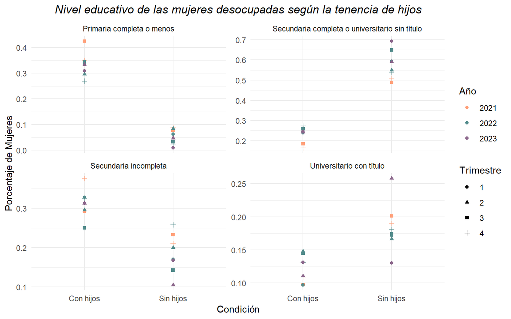

[figure not shown]

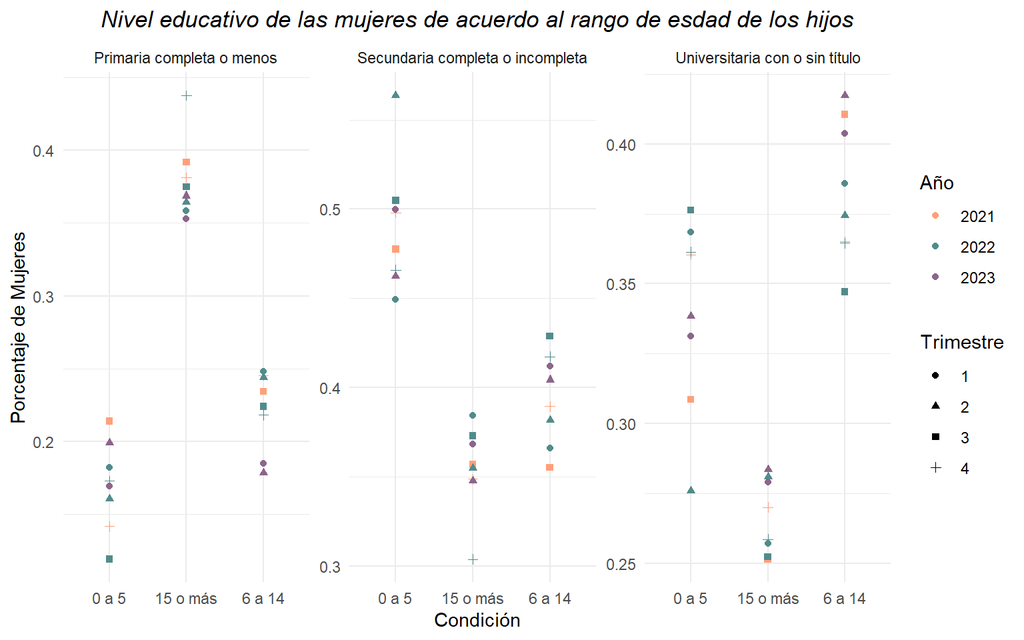

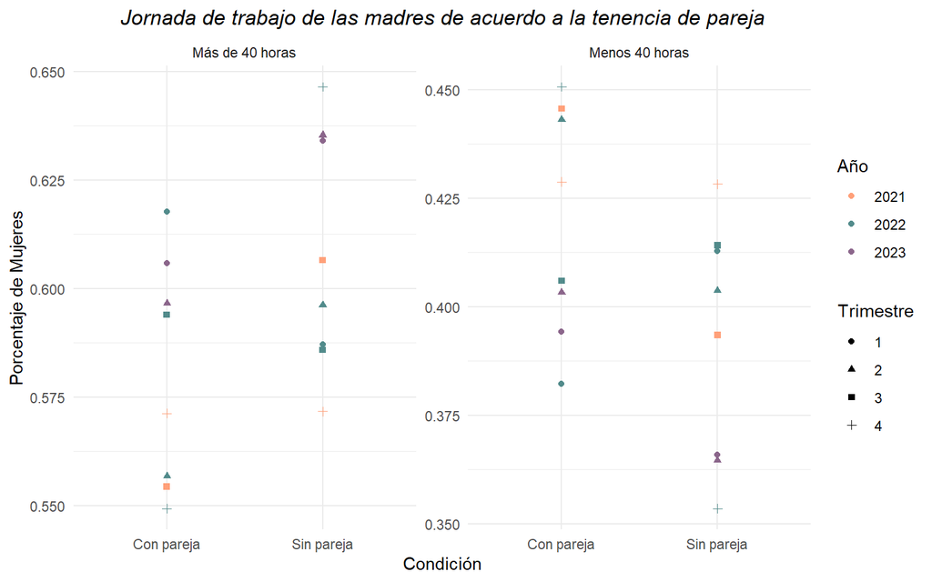

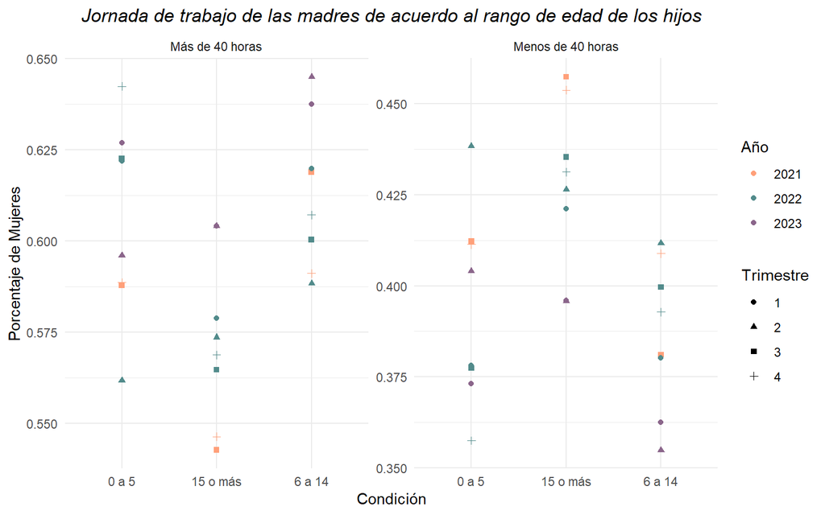

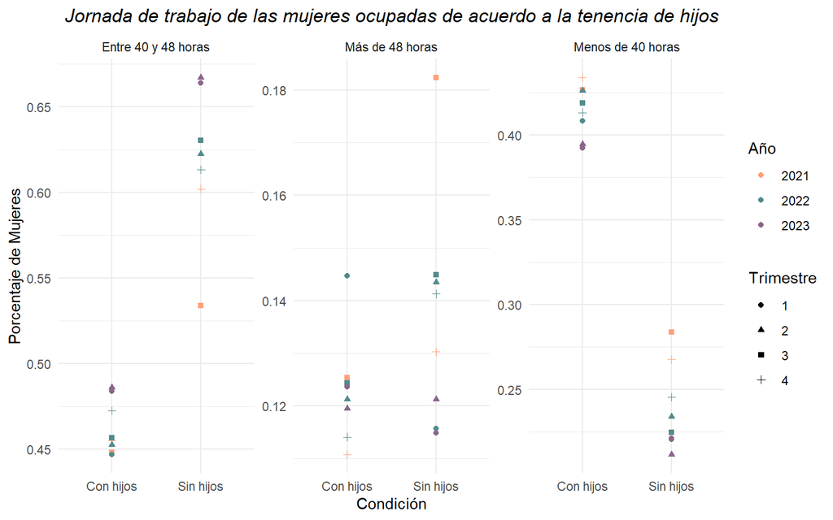

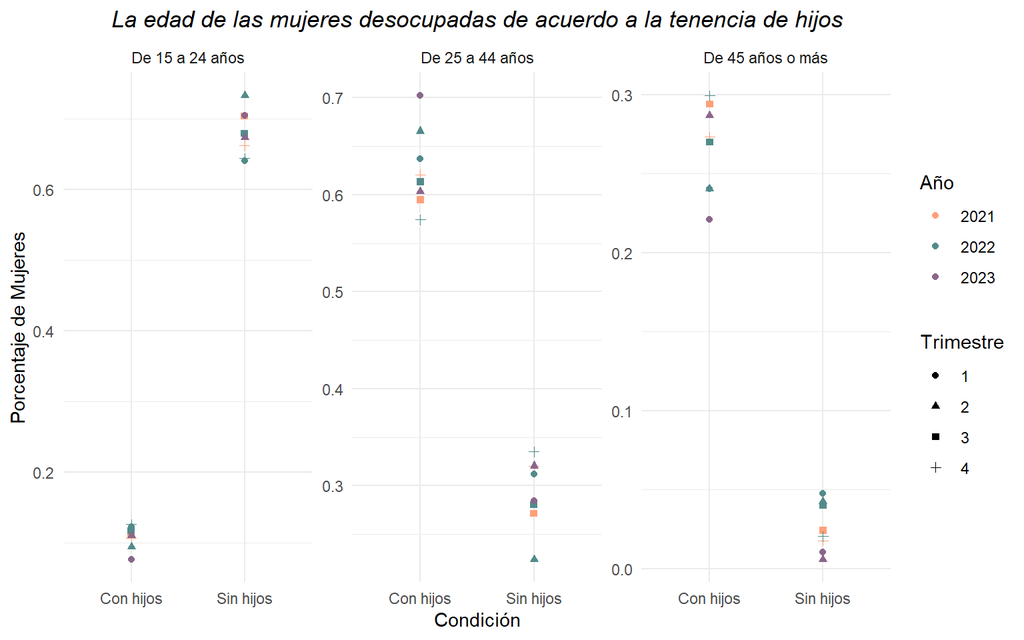

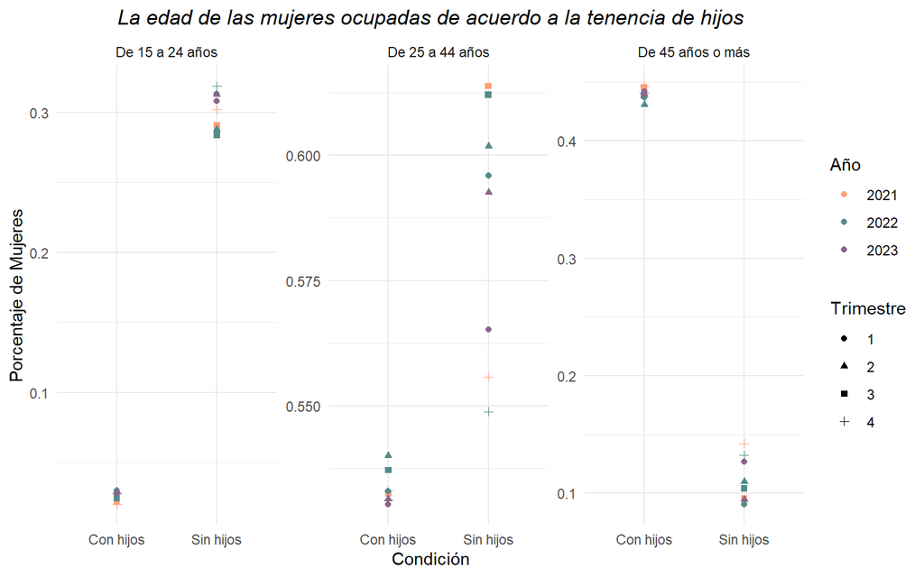

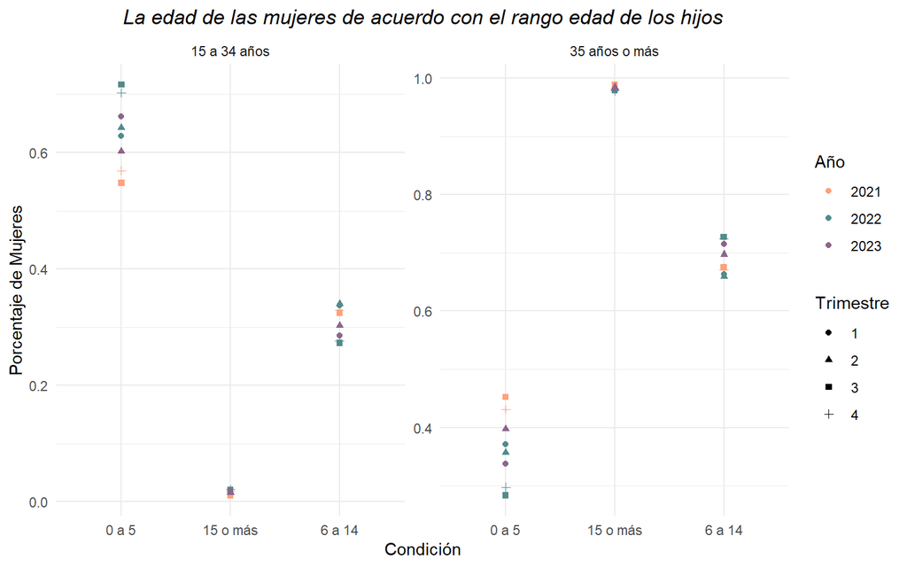

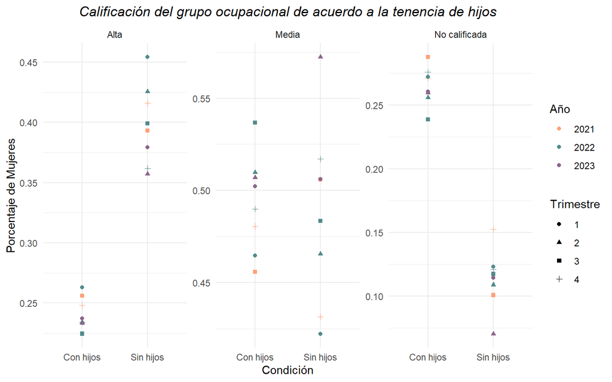

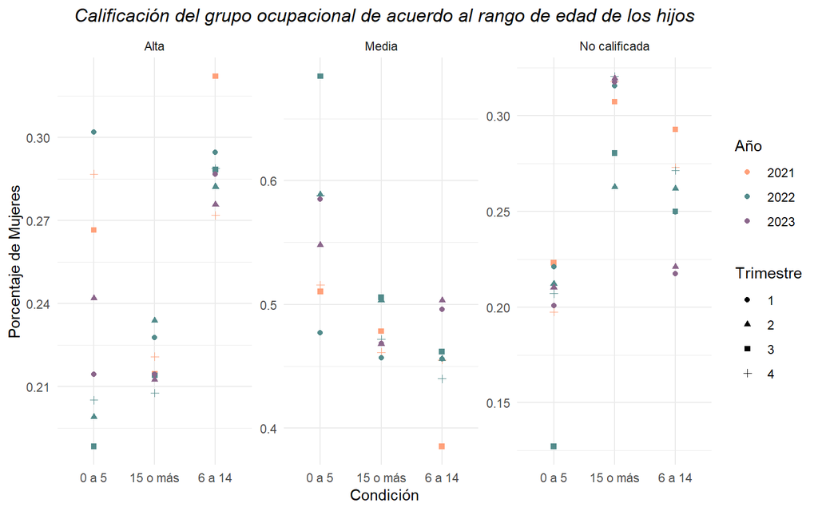

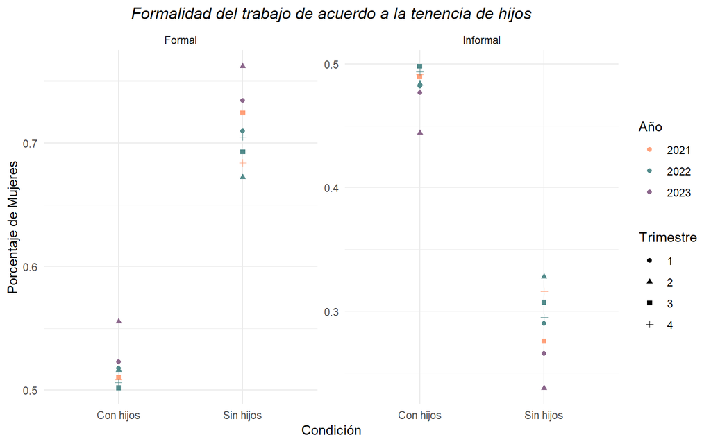

[2 more figures not shown]

```r
index <- 0
for (i in list_of_df2) {
  index <- index + 1
  colnames(i) <- gsub("[.]", " ", colnames(i))
  datos_long <- gather(i, Variable, Valor, -(Año:Total))
  cols1 <- c("#FFA07A", "#528B8B", "#8B668B", "#8B0A50")

  plot <- ggplot(data=datos_long, aes(x=factor(Condición), y = Valor, col= factor(Año), shape=factor(Trimestre))) +
    geom_point() + labs( x = "Condición", y = "Porcentaje de Mujeres", col = "Año", shape = "Trimestre") + ggtitle(row_names[[index]]) +
    scale_color_manual(values = cols1) +
    facet_wrap(~Variable, scales = "free_y") +
    theme_minimal() + theme(plot.title = element_text(face="italic", hjust = 0.5))

  print(plot)
}
```

## Gráficos de barras porcentuales

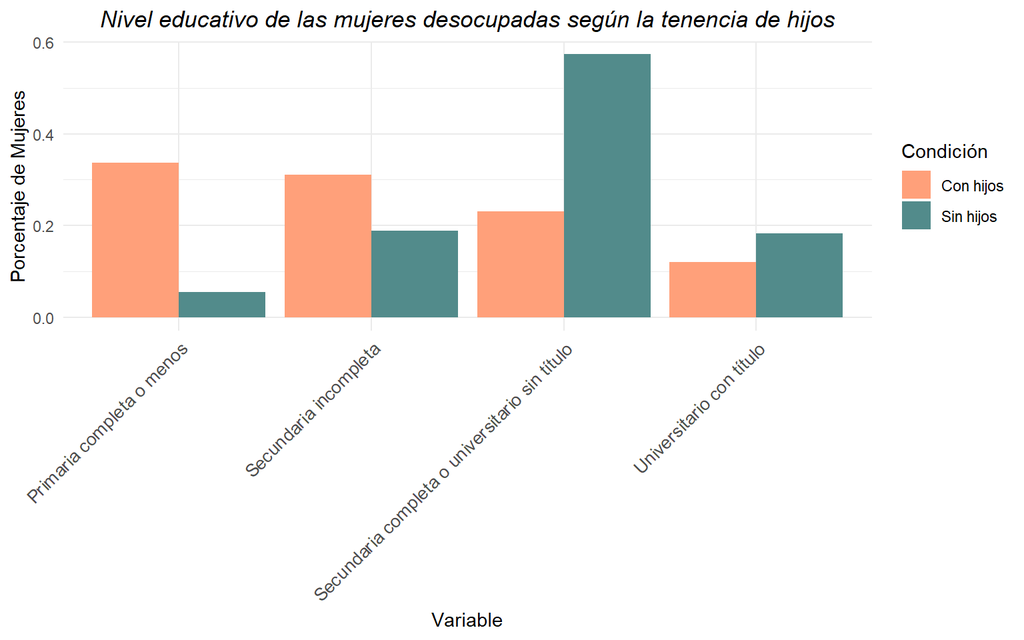

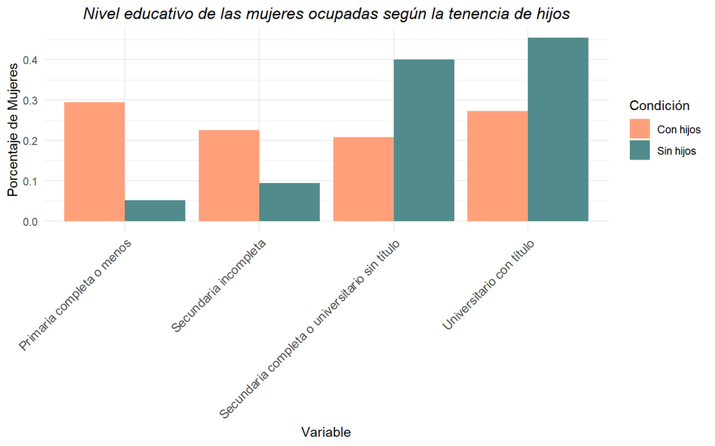

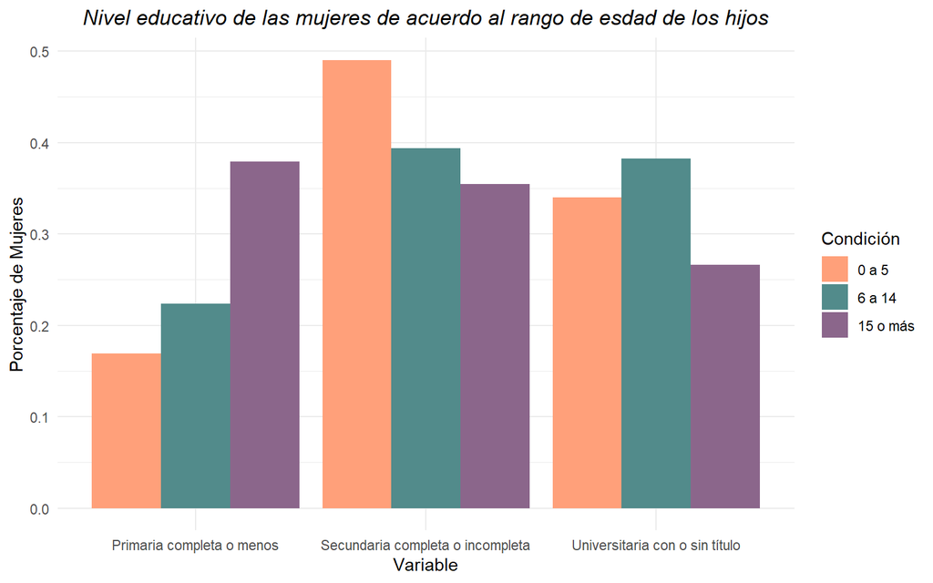

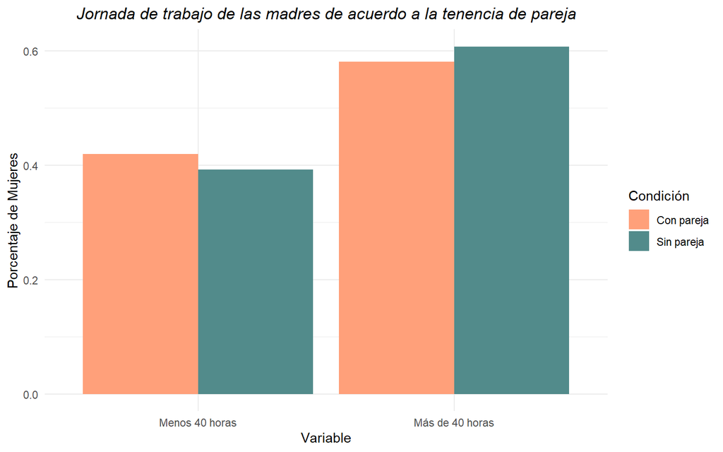

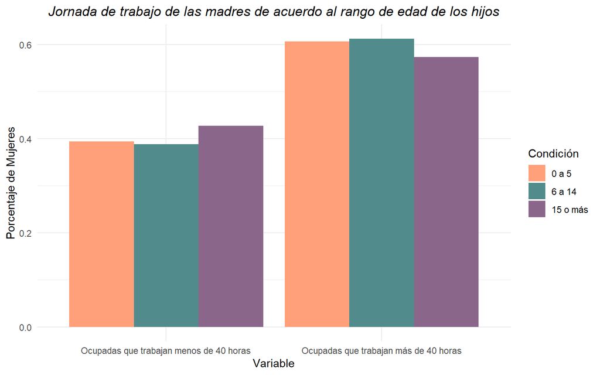

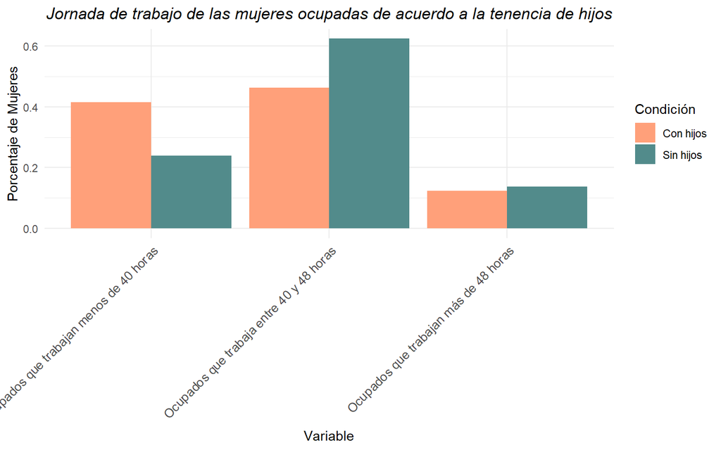

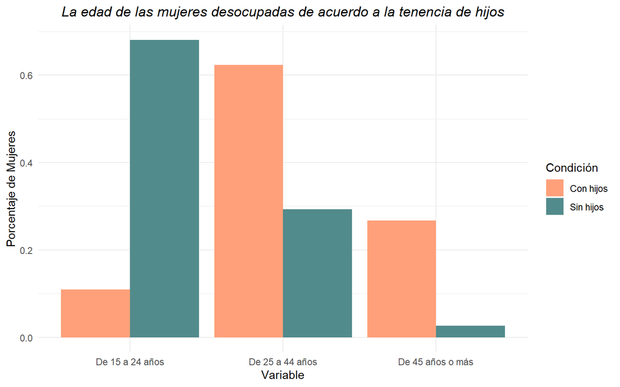

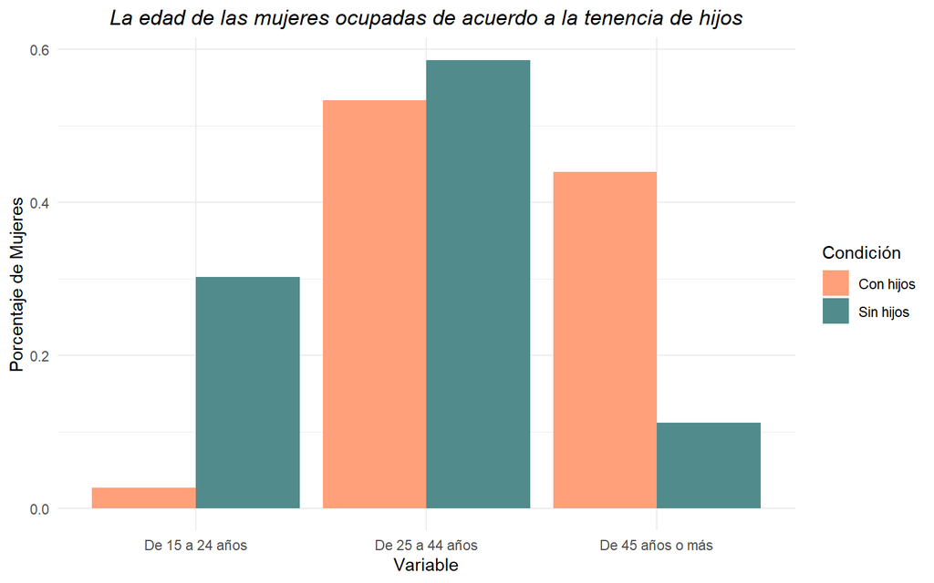

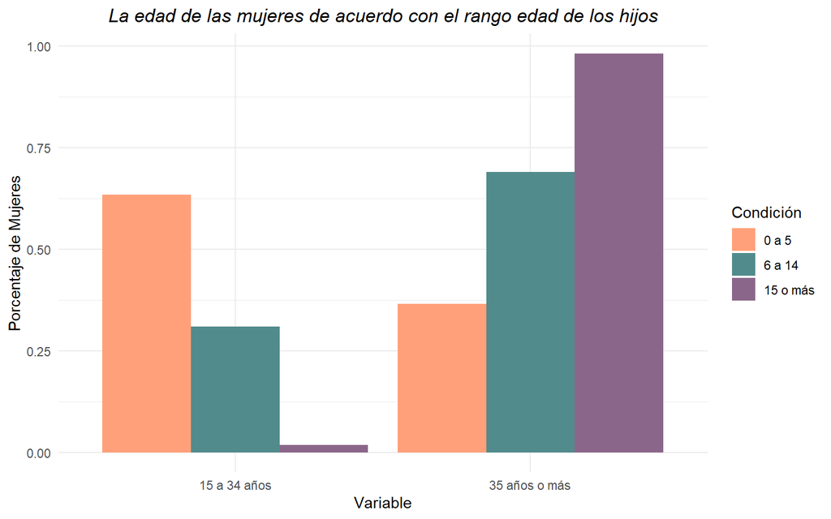

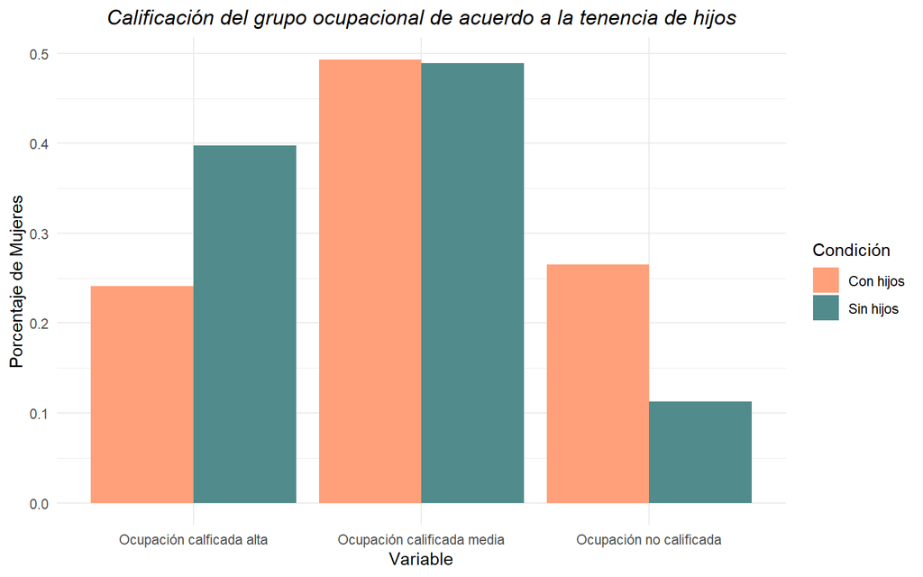

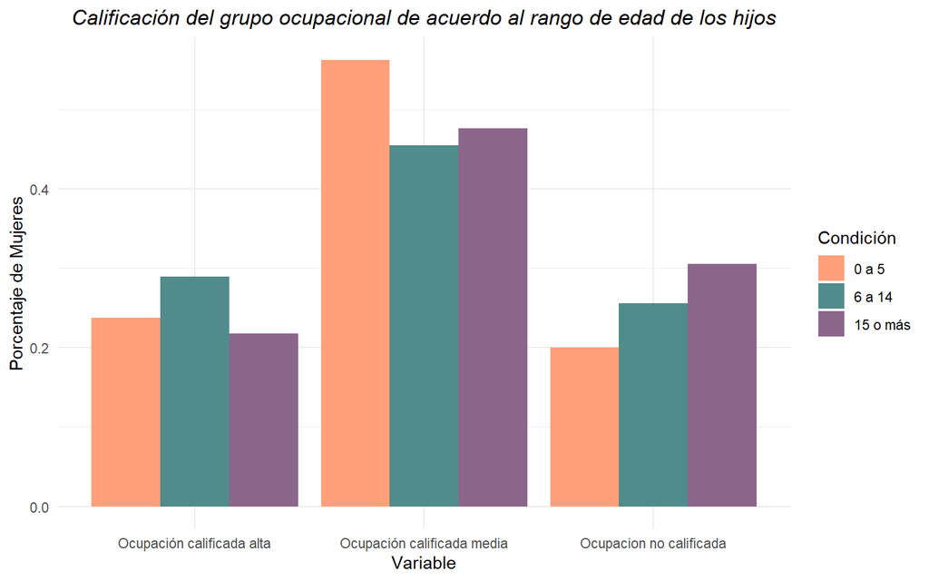

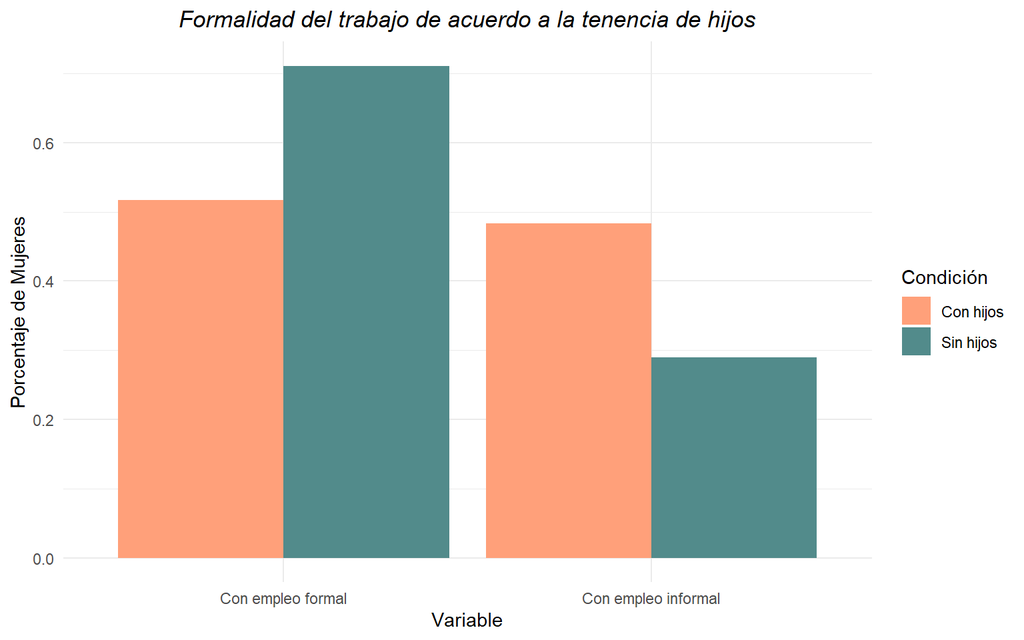

[2 more figures not shown]

```r
for (i in 1:length(tables_barplots)) {
  datos<- tables_barplots[[i]]
  cols1 <- c("#FFA07A", "#528B8B", "#8B668B", "#8B0A50")
  cols2 <- c("#9932CC", "#B22222", "#698B22", "#CD6889")
  colnames(datos) <- gsub("[.]", " ", colnames(datos))
  dataframe<- as.data.frame(datos)

  plot <- ggplot(dataframe, aes(x = Var2, y = Freq, fill= Condicion ) ) +
    labs(x = "Variable", y = "Porcentaje de Mujeres") + ggtitle(row_names[[i]]) +
    geom_bar(width = 0.9, stat = "identity", position = position_dodge()) +
    scale_fill_manual(values = cols1, "Condición") +
    theme_minimal()

  if(i <= 2 | i == 6){
    plot <- plot + theme(plot.title = element_text(face="italic", hjust = 0.5), axis.text.x = element_text(size = 10, angle = 45, hjust=1))
  } else {
    plot <- plot + theme(plot.title = element_text(face="italic", hjust = 0.5))
  }
  print(plot)

}
```